# Regional Application at In Situ SDD Locations

B Steele, Colorado State University, ROSSyndicate

last updated Sep 25, 2026

This script applies the production 10-seed XGBoost ensemble (`04_make_models.ipynb`) to every Landsat observation at every location in the region with quality-controlled in situ Secchi disc depth (SDD) data. It asks how many additional SDD observations remote sensing provides at those same locations.

That number is not simply the siteSR row count. An estimate only counts if every one of these conditions holds:

1. the scene passes the same siteSR QA used to build the training data (`01_filter_AquaMatch_Data.Rmd`: geometry and regional HUC4 scoping, scene metadata QA, and band RANSAC);
2. it comes from a Landsat mission represented in training;
3. it falls within the seasonal window of the training matchups (the central 98% of their day of year), which excludes ice-season scenes the model has effectively never seen;
4. every model input (bands, LakeCat catchment metrics, gridMET antecedent weather) is available;
5. every feature falls within the range of the training data (the literal “training box”);
6. the observation falls inside the model’s area of applicability (AOA; Meyer & Pebesma 2021), a multivariate dissimilarity check against the training data that is weighted by each feature’s contribution to the model; and
7. the estimate is physically plausible: no shallower than the shallowest SDD in the training data. Tree ensembles can return small negative values for very turbid water.

Counts are reported at the level of physical *locations* rather than `siteSR_id`s or `MonitoringLocationIdentifier`s. Following `01_filter_AquaMatch_Data.Rmd`, sites within 100 m of each other on the same waterbody are one location. Otherwise, a station listed under both its WQP and its NWIS identifier would be counted twice on both the in situ and remote sensing sides.

The slow steps (site characteristic fetches, gridMET pulls, and prediction) are cached to `aquamatch_files/application/`. Re-running loads from cache. Set `FORCE_REFRESH_CACHE <- TRUE` to rebuild. Outputs read by `manuscript_tables_figures.Rmd` are written to `aquamatch_files/application/`.

Before counting estimates, the ensemble is assessed on the matchups `02_make_matches.Rmd` set aside because a closer-in-time image existed for the same in situ sample (see “Model performance on superseded matchups”). These are image–field pairs from the same filtered record the model was built from, passed through the same checks as the application.

## Setup

```r
library(arrow)
library(tidyverse)
library(sf)
library(igraph)
library(elevatr)
library(StreamCatTools)
library(parallel)
library(climateR)
library(data.table)
library(xgboost)
library(jsonlite)
library(RANN)

log <- function(...) cat(sprintf("[%s] ", format(Sys.time(), "%H:%M:%S")), sprintf(...), "\n")

AQUAMATCH_DIR <- "regional_clarity/aquamatch_files"
SITES_META_PATH <- file.path(AQUAMATCH_DIR, "downloads", "siteSR_collated_WQP_NWIS_sites_with_NHD_info_2025-06-04.csv")
SITESR_RAW_PATH <- file.path(AQUAMATCH_DIR, "downloads", "siteSR_DSWE1_LS7corr.parquet")
SITESR_QA_PATH <- file.path(AQUAMATCH_DIR, "siteSR_DSWE1_regional_band_filtered.parquet")
SDD_QC_PATH <- file.path(AQUAMATCH_DIR, "sdd_quality_filter.parquet")
TRAINING_PATH <- file.path(AQUAMATCH_DIR, "base_with_splits.parquet")
MODEL_DIR <- file.path("regional_clarity", "xg_models", "v3_production")
ENSEMBLE_SEEDS <- 601:610

OUT_DIR <- file.path(AQUAMATCH_DIR, "application")
dir.create(OUT_DIR, showWarnings = FALSE)
FORCE_REFRESH_CACHE <- FALSE

# identical to python/features.py; see CATCHMENT_WINSORIZE_CAP_SQKM there
CATCHMENT_WINSORIZE_CAP_SQKM <- 617.1
N_WORKERS <- 8
```

## In situ SDD stations

The in situ baseline is the quality-controlled regional SDD record that feeds matchup creation (`01_filter_AquaMatch_Data.Rmd`, the “RANSAC inliers” step): tier/flag QC, the regional HUC4 restriction, and removal of per-site RANSAC outliers. Sites with too few observations to run RANSAC (`is_inlier` missing) are kept, as they are in `01`.

```r
sdd <- read_parquet(SDD_QC_PATH,
                    col_select = c("MonitoringLocationIdentifier", "ActivityStartDate",
                                   "harmonized_value", "is_inlier")) %>%
  filter(is.na(is_inlier) | is_inlier) %>%
  mutate(date = as.Date(ActivityStartDate))

log("in situ SDD: %s rows, %s stations, %s station-days", nrow(sdd),
    n_distinct(sdd$MonitoringLocationIdentifier),
    nrow(distinct(sdd, MonitoringLocationIdentifier, date)))
```

```
## [15:52:45]  in situ SDD: 35183 rows, 2783 stations, 30208 station-days
```

## Link stations to siteSR sites and physical locations

AquaMatch’s site table carries both the WQP-style `MonitoringLocationIdentifier` (as `loc_id`) and, for NWIS-sourced sites, the bare USGS station number (the WQP identifier is `USGS-` + that number). A station can map to more than one `siteSR_id` (e.g. `WQP_*` and `NWIS_*` entries for the same USGS station).

```r
sites_meta <- read_csv(SITES_META_PATH, show_col_types = FALSE,
                       col_select = c(siteSR_id, loc_id, source, WGS84_Latitude, WGS84_Longitude,
                                      wb_nhd_id, wb_nhd_source, flag_wb, flag_optical_shoreline)) %>%
  mutate(MonitoringLocationIdentifier = if_else(source == "NWIS", paste0("USGS-", loc_id), loc_id))

station_sites <- sites_meta %>%
  filter(MonitoringLocationIdentifier %in% sdd$MonitoringLocationIdentifier) %>%
  distinct(siteSR_id, .keep_all = TRUE)

stopifnot("some in situ stations have no AquaMatch site record" =
            all(unique(sdd$MonitoringLocationIdentifier) %in% station_sites$MonitoringLocationIdentifier))
log("%s stations -> %s siteSR_ids", n_distinct(station_sites$MonitoringLocationIdentifier),
    nrow(station_sites))
```

```
## [15:52:50]  2783 stations -> 3221 siteSR_ids
```

Group those `siteSR_id`s into physical locations with the same rule as `01_filter_AquaMatch_Data.Rmd`: within 100 m and on the same NHD waterbody, with grouping transitive through connected components. A site with no matched waterbody is only grouped with itself.

```r
site_pts <- st_as_sf(station_sites, coords = c("WGS84_Longitude", "WGS84_Latitude"),
                     crs = 4326, remove = FALSE)
within_100m <- st_is_within_distance(site_pts, dist = 100)
wb <- station_sites$wb_nhd_id
within_100m_same_wb <- Map(function(nbrs, i) {
  keep <- nbrs == i | (!is.na(wb[nbrs]) & !is.na(wb[i]) & wb[nbrs] == wb[i])
  nbrs[keep]
}, within_100m, seq_along(within_100m))

station_sites <- station_sites %>%
  mutate(location_id = components(graph_from_adj_list(within_100m_same_wb, mode = "all"))$membership)

# one location per station: a station whose siteSR_ids land in different
# locations (rare; different coordinates across sources) is assigned to the
# location holding most of its siteSR_ids
station_location <- station_sites %>%
  count(MonitoringLocationIdentifier, location_id) %>%
  slice_max(n, n = 1, with_ties = FALSE, by = MonitoringLocationIdentifier) %>%
  select(MonitoringLocationIdentifier, location_id)

insitu_location_days <- sdd %>%
  inner_join(station_location, by = "MonitoringLocationIdentifier") %>%
  distinct(location_id, date)

log("%s stations -> %s physical locations; %s in situ location-days",
    nrow(station_location), n_distinct(station_location$location_id), nrow(insitu_location_days))
```

```
## [15:52:50]  2783 stations -> 2373 physical locations; 28389 in situ location-days
```

## siteSR observations at in situ locations

Step 0 is every siteSR observation at these locations before any QA, counted from the national concatenated siteSR file. Step 1 is the QA’d regional siteSR file written by `01_filter_AquaMatch_Data.Rmd` (geometry and HUC4 scoping, scene metadata QA, and band RANSAC). Because `01` scopes by HUC4 and site geometry, a location can drop out entirely at step 1; those locations are not observable in this framework.

```r
location_lookup <- station_sites %>% select(siteSR_id, location_id)

raw_counts_cache <- file.path(OUT_DIR, "sitesr_raw_location_days.parquet")
if (!FORCE_REFRESH_CACHE && file.exists(raw_counts_cache)) {
  sitesr_raw_location_days <- read_parquet(raw_counts_cache)
} else {
  sitesr_raw_location_days <- open_dataset(SITESR_RAW_PATH) %>%
    select(siteSR_id, date) %>%
    filter(siteSR_id %in% location_lookup$siteSR_id) %>%
    collect() %>%
    mutate(date = as.Date(date)) %>%
    inner_join(location_lookup, by = "siteSR_id") %>%
    distinct(location_id, date)
  write_parquet(sitesr_raw_location_days, raw_counts_cache)
}

sitesr_qa <- read_parquet(SITESR_QA_PATH) %>%
  filter(siteSR_id %in% location_lookup$siteSR_id) %>%
  mutate(date = as.Date(date)) %>%
  inner_join(location_lookup, by = "siteSR_id")

log("pre-QA: %s location-days at %s locations", nrow(sitesr_raw_location_days),
    n_distinct(sitesr_raw_location_days$location_id))
```

```
## [15:52:54]  pre-QA: 1467744 location-days at 2159 locations
```

```r
log("post-QA: %s rows, %s location-days at %s locations", nrow(sitesr_qa),
    nrow(distinct(sitesr_qa, location_id, date)), n_distinct(sitesr_qa$location_id))
```

```
## [15:52:54]  post-QA: 1076625 rows, 746489 location-days at 1826 locations
```

## Site characteristics

Elevation and LakeCat catchment metrics per `siteSR_id`, following `pull_site_characteristics.Rmd`. Sites already in that script’s output (`site_characteristics.feather`, the training sites) are reused, and only the remaining sites are fetched. `shore_flag` uses the definition from `03_split_data.ipynb`.

```r
site_char_cache <- file.path(OUT_DIR, "application_site_characteristics.feather")
qa_sites <- station_sites %>% filter(siteSR_id %in% unique(sitesr_qa$siteSR_id))

stopifnot("some sites resolve to a non-NHDPlusv2 waterbody source - LakeCat join is not safe as-is" =
            all(qa_sites$wb_nhd_source == "NHDPlusv2" | is.na(qa_sites$wb_nhd_source)))

if (!FORCE_REFRESH_CACHE && file.exists(site_char_cache)) {
  site_char <- read_feather(site_char_cache)
} else {
  existing <- read_feather(file.path(AQUAMATCH_DIR, "site_characteristics.feather")) %>%
    filter(siteSR_id %in% qa_sites$siteSR_id) %>%
    select(siteSR_id, elevation_m, catchment_area_sqkm, starts_with("pct_"))
  to_fetch <- qa_sites %>% filter(!siteSR_id %in% existing$siteSR_id)
  log("site characteristics: %s cached from training, %s to fetch", nrow(existing), nrow(to_fetch))

  pts_sf <- st_as_sf(to_fetch, coords = c("WGS84_Longitude", "WGS84_Latitude"), crs = 4326)
  elev <- get_elev_point(pts_sf, src = "aws", z = 9) %>%
    st_drop_geometry() %>%
    select(siteSR_id, elevation_m = elevation)

  lakecat_metrics <- paste(c(
    "pctimp2006", "pcturbhi2006", "pcturblo2006", "pcturbmd2006", "pcturbop2006",
    "pctconif2006", "pctdecid2006", "pctmxfst2006",
    "pcthbwet2006", "pctwdwet2006", "pctcrop2006"
  ), collapse = ",")
  comids <- unique(na.omit(as.character(to_fetch$wb_nhd_id)))
  chunks <- split(comids, ceiling(seq_along(comids) / 200))
  # a chunk where none of the comids are LakeCat-covered throws rather than
  # returning empty, so catch per chunk
  lakecat <- map(chunks, \(ch) {
    tryCatch(lc_get_data(comid = paste(ch, collapse = ","), metric = lakecat_metrics,
                         aoi = "catchment", showAreaSqKm = TRUE),
             error = function(e) { log("LakeCat chunk failed: %s", conditionMessage(e)); tibble() })
  }) %>%
    list_rbind() %>%
    mutate(comid = as.character(comid),
           pct_forest_2006 = pctconif2006cat + pctdecid2006cat + pctmxfst2006cat,
           pct_wetland_2006 = pcthbwet2006cat + pctwdwet2006cat,
           pct_urban_2006 = pcturbhi2006cat + pcturblo2006cat + pcturbmd2006cat + pcturbop2006cat) %>%
    select(comid, catchment_area_sqkm = catareasqkm,
           pct_impervious_2006 = pctimp2006cat, pct_urban_2006, pct_forest_2006,
           pct_cropland_2006 = pctcrop2006cat, pct_wetland_2006)

  fetched <- to_fetch %>%
    mutate(comid = as.character(wb_nhd_id)) %>%
    select(siteSR_id, comid) %>%
    left_join(elev, by = "siteSR_id") %>%
    left_join(lakecat, by = "comid") %>%
    select(-comid)

  site_char <- bind_rows(existing, fetched) %>%
    left_join(qa_sites %>%
                transmute(siteSR_id,
                          shore_flag = as.numeric(flag_wb == 1 | flag_optical_shoreline == 1)),
              by = "siteSR_id")
  write_feather(site_char, site_char_cache)
}

log("sites with LakeCat data: %s / %s", sum(!is.na(site_char$pct_impervious_2006)), nrow(site_char))
```

```
## [15:52:54]  sites with LakeCat data: 2512 / 2512
```

## Antecedent weather (gridMET)

gridMET is a 1/24° grid, and many sites share a cell. Weather is therefore fetched once per cell (at the cell center) over the full date range needed by that cell’s siteSR observations, then assigned back to every site in the cell. Rolling summaries follow `pull_weather_summaries.Rmd` and cover the *w* days strictly before the image date.

```r
GRIDMET_RES <- 1 / 24
GRIDMET_LON0 <- -124.766666666667  # westernmost cell center
GRIDMET_LAT0 <- 49.4               # northernmost cell center
MAX_WINDOW_DAYS <- 30
WINDOWS <- c(1, 3, 7, 30)
VARS <- c("pr", "tmmx", "tmmn", "srad")

site_cells <- qa_sites %>%
  transmute(siteSR_id,
            col = round((WGS84_Longitude - GRIDMET_LON0) / GRIDMET_RES),
            row = round((GRIDMET_LAT0 - WGS84_Latitude) / GRIDMET_RES),
            cell_id = paste(col, row, sep = "_"),
            cell_lon = GRIDMET_LON0 + col * GRIDMET_RES,
            cell_lat = GRIDMET_LAT0 - row * GRIDMET_RES)

cell_ranges <- sitesr_qa %>%
  distinct(siteSR_id, date) %>%
  inner_join(site_cells, by = "siteSR_id") %>%
  summarise(min_date = min(date) - (MAX_WINDOW_DAYS + 5), max_date = max(date),
            .by = c(cell_id, cell_lon, cell_lat))

log("%s sites fall in %s gridMET cells", nrow(site_cells), nrow(cell_ranges))
```

```
## [15:52:55]  2512 sites fall in 1183 gridMET cells
```

```r
weather_raw_cache <- file.path(OUT_DIR, "application_weather_raw.feather")

if (!FORCE_REFRESH_CACHE && file.exists(weather_raw_cache)) {
  weather_raw <- read_feather(weather_raw_cache)
} else {
  fetch_one <- function(i, cell_ranges, VARS) {
    row <- cell_ranges[i, ]
    fetch <- function() {
      pt <- sf::st_as_sf(data.frame(lon = row$cell_lon, lat = row$cell_lat),
                         coords = c("lon", "lat"), crs = 4326)
      res <- climateR::getGridMET(AOI = pt, varname = VARS,
                                  startDate = as.character(row$min_date),
                                  endDate = as.character(row$max_date))
      res$cell_id <- row$cell_id
      res
    }
    tryCatch(fetch(), error = function(e) {
      Sys.sleep(5)
      tryCatch(fetch(), error = function(e2) data.frame(cell_id = row$cell_id, error = conditionMessage(e2)))
    })
  }

  t0 <- Sys.time()
  cl <- makeCluster(N_WORKERS, type = "PSOCK")
  clusterEvalQ(cl, { suppressMessages(library(climateR)); suppressMessages(library(sf)) })
  results <- parLapply(cl, seq_len(nrow(cell_ranges)), fetch_one,
                       cell_ranges = cell_ranges, VARS = VARS)
  stopCluster(cl)
  log("gridMET fetch took %.1f min", as.numeric(difftime(Sys.time(), t0, units = "mins")))

  failed <- Filter(function(x) "error" %in% names(x), results)
  log("succeeded: %s cells, failed: %s cells", length(results) - length(failed), length(failed))
  if (length(failed) > 0) write_csv(bind_rows(failed), file.path(OUT_DIR, "gridmet_fetch_failures.csv"))

  weather_raw <- bind_rows(Filter(function(x) !"error" %in% names(x), results))
  write_feather(weather_raw, weather_raw_cache)
}
```

```r
weather_summary_cache <- file.path(OUT_DIR, "application_weather_summaries.feather")

if (!FORCE_REFRESH_CACHE && file.exists(weather_summary_cache)) {
  weather_summaries <- as.data.table(read_feather(weather_summary_cache))
} else {
  weather <- as.data.table(weather_raw)[, .(cell_id, date = as.Date(date),
                                             precip_mm = pr,
                                             tmax_degC = tmmx - 273.15,
                                             tmin_degC = tmmn - 273.15,
                                             srad_Wm2 = srad)]
  weather[, tmean_degC := (tmax_degC + tmin_degC) / 2]

  # regular daily series per cell, so the rolling windows count calendar days
  full_days <- weather[, .(date = seq(min(date), max(date), by = "1 day")), by = cell_id]
  weather <- weather[full_days, on = .(cell_id, date)]
  setorder(weather, cell_id, date)

  for (w in WINDOWS) {
    weather[, paste0("precip_mm_prev", w) := frollsum(precip_mm, n = w), by = cell_id]
    weather[, paste0("tmax_degC_prev", w) := frollmax(tmax_degC, n = w), by = cell_id]
    weather[, paste0("tmean_degC_prev", w) := frollmean(tmean_degC, n = w), by = cell_id]
    weather[, paste0("tmin_degC_prev", w) := -frollmax(-tmin_degC, n = w), by = cell_id]
    weather[, paste0("srad_Wm2_prev", w) := frollmean(srad_Wm2, n = w), by = cell_id]
  }
  # shift so window w on `date` covers the w days strictly BEFORE date
  weather[, date := date + 1]
  weather_summaries <- weather[, c("cell_id", "date", grep("_prev", names(weather), value = TRUE)), with = FALSE]
  write_feather(as.data.frame(weather_summaries), weather_summary_cache)
}
log("weather summaries: %s cell-days", nrow(weather_summaries))
```

```
## [15:52:59]  weather summaries: 16918529 cell-days
```

## Assemble model inputs

The band columns in the QA’d siteSR file are already harmonized to Landsat 7 (Gardner et al.; `*_corr_7`). Spectral indices and the coarsening of site features are R ports of `python/features.py` (`add_spectral_indices()` and `coarsen_site_features()`). The same function is applied to the training data below, so the applicability checks compare like with like.

```r
TRAINING_MISSIONS <- c("LT04", "LT05", "LE07", "LC08", "LC09")

add_features <- function(df) {
  df %>%
    mutate(BR = blue_corr7 / red_corr7,
           BG = blue_corr7 / green_corr7,
           NR = nir_corr7 / red_corr7,
           GR = green_corr7 / red_corr7,
           fai = nir_corr7 - (red_corr7 + (swir1_corr7 - red_corr7) * ((830 - 660) / (1650 - 660))),
           NDVI = (nir_corr7 - red_corr7) / (nir_corr7 + red_corr7),
           NDSSI = (blue_corr7 - nir_corr7) / (blue_corr7 + nir_corr7),
           NDWI = (green_corr7 - nir_corr7) / (green_corr7 + nir_corr7),
           MNDWI = (green_corr7 - swir1_corr7) / (green_corr7 + swir1_corr7)) %>%
    mutate(across(c(BR, BG, NR, GR, fai, NDVI, NDSSI, NDWI, MNDWI), ~ if_else(is.finite(.x), .x, NA_real_)),
           catchment_area_sqkm = if_else(catchment_area_sqkm > 0,
                                         10^round(log10(pmin(catchment_area_sqkm, CATCHMENT_WINSORIZE_CAP_SQKM)), 1),
                                         catchment_area_sqkm),
           across(c(pct_impervious_2006, pct_urban_2006, pct_forest_2006,
                    pct_cropland_2006, pct_wetland_2006), ~ round(.x, 0)))
}
```

```r
model_input <- sitesr_qa %>%
  select(siteSR_id, location_id, date, mission,
         red_corr7 = red_corr_7, green_corr7 = green_corr_7, blue_corr7 = blue_corr_7,
         nir_corr7 = nir_corr_7, swir1_corr7 = swir1_corr_7, swir2_corr7 = swir2_corr_7,
         temp_corr7 = surfacetemp_corr_7) %>%
  mutate(atm_corr_LaSRC = as.integer(mission %in% c("LC08", "LC09"))) %>%
  left_join(site_char, by = "siteSR_id") %>%
  left_join(site_cells %>% select(siteSR_id, cell_id), by = "siteSR_id") %>%
  left_join(as.data.frame(weather_summaries), by = c("cell_id", "date")) %>%
  add_features() %>%
  # the data.table class carries through the join otherwise, which breaks
  # plain `df[, feats]` column selection below
  as_tibble()

log("model input: %s rows", nrow(model_input))
```

```
## [15:53:00]  model input: 1076625 rows
```

## Predict with the 10-seed ensemble

Each seed’s saved feature set and four fold models are used as trained. The prediction for a row is the mean over all 40 models, and the spread across the 10 seed means is kept as a measure of ensemble disagreement.

```r
seed_feats <- map(ENSEMBLE_SEEDS, \(s) {
  fromJSON(file.path(MODEL_DIR, paste0("seed", s), "final_tune_xgboost.json"))$features
}) %>%
  set_names(ENSEMBLE_SEEDS)
model_feats <- sort(unique(unlist(seed_feats)))
```

```r
pred_cache <- file.path(OUT_DIR, "application_predictions.parquet")

if (!FORCE_REFRESH_CACHE && file.exists(pred_cache)) {
  preds <- read_parquet(pred_cache)
} else {
  seed_preds <- map(ENSEMBLE_SEEDS, \(s) {
    feats <- seed_feats[[as.character(s)]]
    X <- as.matrix(model_input[, feats])
    fold_preds <- map(1:4, \(fold) {
      booster <- xgb.load(file.path(MODEL_DIR, paste0("seed", s), paste0("xgboost_fold", fold, ".json")))
      predict(booster, X)
    })
    log("seed%s predicted", s)
    rowMeans(do.call(cbind, fold_preds))
  })
  seed_mat <- do.call(cbind, seed_preds)
  preds <- tibble(pred_sdd = rowMeans(seed_mat), pred_seed_sd = apply(seed_mat, 1, sd))
  write_parquet(preds, pred_cache)
}
stopifnot(nrow(preds) == nrow(model_input))
model_input <- bind_cols(model_input, preds)
```

## Applicability checks

### Training reference

The reference is the cross-validation pool that trained the ensemble (every non-holdout row of `base_with_splits.parquet`), with features engineered by the same function as above.

```r
training <- read_parquet(TRAINING_PATH) %>%
  mutate(date = as.Date(date)) %>%
  add_features()
train_pool <- training %>% filter(!is_holdout)
log("training reference: %s CV-pool rows", nrow(train_pool))
```

```
## [15:53:00]  training reference: 8937 CV-pool rows
```

### Feature range (“training box”)

An observation passes when every model input used by any seed lies within the minimum and maximum of that feature in the training pool. Tree ensembles do not extrapolate: outside the training range, a prediction flattens at the value of the outermost leaf, so these estimates carry no information about how SDD responds beyond the sampled conditions.

```r
feature_ranges <- train_pool %>%
  summarise(across(all_of(model_feats), list(min = ~ min(.x, na.rm = TRUE), max = ~ max(.x, na.rm = TRUE)))) %>%
  pivot_longer(everything(), names_to = c("feature", ".value"), names_pattern = "(.*)_(min|max)$")

in_range <- function(df) {
  ok <- rep(TRUE, nrow(df))
  for (i in seq_len(nrow(feature_ranges))) {
    x <- df[[feature_ranges$feature[i]]]
    ok <- ok & !is.na(x) & x >= feature_ranges$min[i] & x <= feature_ranges$max[i]
  }
  ok
}

feature_complete <- function(df) complete.cases(df[, model_feats])
```

### Seasonal window

The training matchups are concentrated in the open-water season (about 85% in May–October; under 4% in November–March). The area of applicability below weights features by their SHAP contribution, and air and surface temperature carry little weight, so it barely distinguishes a January scene from a July scene with similar optics. Ice-season conditions (partial ice cover, winter mixing, snowmelt) are nonetheless outside what the model has learned. An observation therefore has to fall within the day-of-year window spanning the central 98% of the training matchups (1st to 99th percentile).

```r
training_doy <- yday(train_pool$date)
season_window <- round(quantile(training_doy, c(0.01, 0.99)))
in_season <- function(df) between(yday(df$date), season_window[1], season_window[2])
log("seasonal window: day of year %s-%s", season_window[1], season_window[2])
```

```
## [15:53:00]  seasonal window: day of year 70-320
```

### Area of applicability

The dissimilarity index (DI) of Meyer & Pebesma (2021) is computed over the features every seed kept (the same core used for SHAP attribution in `05_evaluate_ensemble.ipynb`). Features are standardized by the training pool’s mean and standard deviation, then weighted by their ensemble mean |SHAP|, so distance is measured in the directions the model relies on. An observation’s DI is the distance to its nearest training observation, divided by the mean pairwise distance within the training pool.

The threshold follows Meyer & Pebesma (2021): the DI of each training observation to its nearest neighbor *in a different cross-validation fold* (the four HUC8-grouped CV-pool partitions, `holdout_part` 1-4), with the threshold set at the upper whisker of that distribution (third quartile + 1.5 × IQR).

```r
shap_weights <- read_csv(file.path(MODEL_DIR, "ensemble_mean_abs_shap.csv"), show_col_types = FALSE)
aoa_feats <- shap_weights$feature
stopifnot(all(aoa_feats %in% model_feats))

centers <- map_dbl(aoa_feats, \(f) mean(train_pool[[f]], na.rm = TRUE))
scales <- map_dbl(aoa_feats, \(f) sd(train_pool[[f]], na.rm = TRUE))
weights <- shap_weights$mean_abs_shap

to_aoa_space <- function(df) {
  X <- as.matrix(df[, aoa_feats])
  X <- sweep(sweep(X, 2, centers), 2, scales, "/")
  sweep(X, 2, weights, "*")
}

# the handful of training rows missing a weather summary (~0.1%) can't be
# placed in feature space and are left out of the reference
train_X <- to_aoa_space(train_pool)
train_complete <- complete.cases(train_X)
train_X <- train_X[train_complete, ]
log("AOA reference: %s of %s CV-pool rows complete", nrow(train_X), length(train_complete))
```

```
## [15:53:00]  AOA reference: 8926 of 8937 CV-pool rows complete
```

```r
# mean pairwise distance within the training pool
d_bar <- mean(dist(train_X))

# cross-fold nearest-neighbor DI for the threshold
train_fold <- train_pool$holdout_part[train_complete]
train_di <- numeric(nrow(train_X))
for (k in unique(train_fold)) {
  in_k <- train_fold == k
  train_di[in_k] <- nn2(train_X[!in_k, ], train_X[in_k, ], k = 1)$nn.dists[, 1] / d_bar
}
aoa_threshold <- boxplot.stats(train_di)$stats[5]

compute_di <- function(df) {
  di <- rep(NA_real_, nrow(df))
  X <- to_aoa_space(df)
  ok <- complete.cases(X)
  di[ok] <- nn2(train_X, X[ok, , drop = FALSE], k = 1)$nn.dists[, 1] / d_bar
  di
}

log("AOA threshold (DI): %.3f", aoa_threshold)
```

```
## [15:53:02]  AOA threshold (DI): 0.385
```

## Model performance on superseded matchups

`02_make_matches.Rmd` pairs each in situ SDD sample with every rain-screened siteSR observation within ±5 days, keeps the one closest in time for training, and sets the rest aside (`regional_sdd_not_closest.parquet`). Those superseded matchups are real image–field pairs that passed every upstream filter but never entered model training as rows, which makes them a direct test of the application setting: an image that is not the one the model was trained on, at a monitored location. Each in situ sample behind them also has a closest-in-time match in the training data, so the field value itself is not new to the model at sites in the cross-validation pool; the images are.

Features follow `03_split_data.ipynb` exactly: harmonized bands from the matchup, the same site characteristics, and antecedent weather anchored on the later of the image and field dates. The 40-model ensemble is applied as above, and the same applicability checks and plausibility floor are applied as in the regional application.

```r
superseded <- read_parquet(file.path(AQUAMATCH_DIR, "regional_sdd_not_closest.parquet")) %>%
  transmute(siteSR_id, date = as.Date(date), mission, obs = harmonized_value,
            field_date = as.Date(harmonized_local_time, tz = "UTC"),
            anchor_date = pmax(date, field_date),
            red_corr7 = red_corr_7, green_corr7 = green_corr_7, blue_corr7 = blue_corr_7,
            nir_corr7 = nir_corr_7, swir1_corr7 = swir1_corr_7, swir2_corr7 = swir2_corr_7,
            temp_corr7 = surfacetemp_corr_7,
            atm_corr_LaSRC = as.integer(mission %in% c("LC08", "LC09"))) %>%
  left_join(site_char, by = "siteSR_id") %>%
  left_join(site_cells %>% select(siteSR_id, cell_id), by = "siteSR_id") %>%
  left_join(as.data.frame(weather_summaries), by = c("cell_id", "anchor_date" = "date")) %>%
  add_features() %>%
  as_tibble()

superseded$pred <- map(ENSEMBLE_SEEDS, \(s) {
  X <- as.matrix(superseded[, seed_feats[[as.character(s)]]])
  map(1:4, \(fold) {
    predict(xgb.load(file.path(MODEL_DIR, paste0("seed", s), paste0("xgboost_fold", fold, ".json"))), X)
  })
}) %>%
  list_flatten() %>%
  do.call(cbind, .) %>%
  rowMeans()

superseded <- superseded %>%
  left_join(training %>% distinct(siteSR_id, is_holdout), by = "siteSR_id") %>%
  mutate(pass_mission = mission %in% TRAINING_MISSIONS,
         pass_season = pass_mission & in_season(.),
         pass_complete = pass_season & feature_complete(.),
         pass_range = pass_complete & in_range(.),
         di = compute_di(.),
         pass_aoa = pass_range & !is.na(di) & di <= aoa_threshold,
         pass_plausible = pass_aoa & pred >= min(train_pool$harmonized_value))

log("superseded matchups: %s rows at %s sites (%s at holdout sites); %s pass every check",
    nrow(superseded), n_distinct(superseded$siteSR_id), sum(superseded$is_holdout, na.rm = TRUE),
    sum(superseded$pass_plausible))
```

```
## [15:53:06]  superseded matchups: 2811 rows at 622 sites (600 at holdout sites); 2714 pass every check
```

```r
superseded_metrics <- function(df) {
  summarise(df, n = n(),
            rmse = sqrt(mean((pred - obs)^2)),
            mae = mean(abs(pred - obs)),
            bias = mean(pred - obs),
            r2 = cor(pred, obs)^2)
}

superseded_validation <- bind_rows(
  superseded %>%
    mutate(group = case_when(!pass_range ~ "outside season or training range",
                             !pass_aoa ~ "outside AOA",
                             !pass_plausible ~ "below plausibility floor",
                             TRUE ~ "passes all checks")),
  superseded %>% mutate(group = "all superseded")
) %>%
  mutate(sites = if_else(is_holdout, "holdout sites", "CV-pool sites")) %>%
  bind_rows(mutate(., sites = "all sites")) %>%
  group_by(sites, group) %>%
  superseded_metrics() %>%
  ungroup()
```

[output not shown]

```r
write_csv(superseded_validation, file.path(OUT_DIR, "superseded_validation.csv"))
write_parquet(superseded %>% select(siteSR_id, date, field_date, mission, obs, pred, is_holdout, di, starts_with("pass_")),
              file.path(OUT_DIR, "superseded_predictions.parquet"))
superseded_validation %>% mutate(across(c(rmse, mae, bias, r2), ~ round(.x, 3)))
```

```
## # A tibble: 13 × 7
##    sites         group                                n  rmse   mae   bias    r2
##    <chr>         <chr>                            <int> <dbl> <dbl>  <dbl> <dbl>
##  1 CV-pool sites all superseded                    2211 1.14  0.808  0.036 0.756
##  2 CV-pool sites below plausibility floor            10 0.238 0.225 -0.225 0.022
##  3 CV-pool sites outside AOA                         14 1.04  0.73   0.46  0.922
##  4 CV-pool sites outside season or training range    55 1.38  0.817 -0.159 0.837
##  5 CV-pool sites passes all checks                 2132 1.14  0.811  0.04  0.746
##  6 all sites     all superseded                    2811 1.20  0.855  0.033 0.723
##  7 all sites     below plausibility floor            10 0.238 0.225 -0.225 0.022
##  8 all sites     outside AOA                         14 1.04  0.73   0.46  0.922
##  9 all sites     outside season or training range    73 1.57  1.04   0.268 0.769
## 10 all sites     passes all checks                 2714 1.20  0.853  0.026 0.717
## 11 holdout sites all superseded                     600 1.41  1.03   0.024 0.599
## 12 holdout sites outside season or training range    18 2.03  1.72   1.57  0.445
## 13 holdout sites passes all checks                  582 1.39  1.00  -0.024 0.613
```

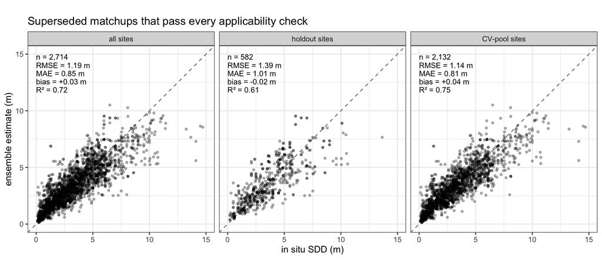

```r
superseded_passing <- superseded %>%
  filter(pass_plausible) %>%
  mutate(sites = if_else(is_holdout, "holdout sites", "CV-pool sites")) %>%
  bind_rows(mutate(., sites = "all sites")) %>%
  mutate(sites = factor(sites, levels = c("all sites", "holdout sites", "CV-pool sites")))

panel_labels <- superseded_validation %>%
  filter(group == "passes all checks") %>%
  mutate(sites = factor(sites, levels = levels(superseded_passing$sites)),
         label = sprintf("n = %s\nRMSE = %.2f m\nMAE = %.2f m\nbias = %+.2f m\nR² = %.2f",
                         format(n, big.mark = ",", trim = TRUE), rmse, mae, bias, r2))

axis_max <- ceiling(max(superseded_passing$obs, superseded_passing$pred))

ggplot(superseded_passing, aes(obs, pred)) +
  geom_abline(linetype = "dashed", colour = "grey50") +
  geom_point(alpha = 0.3, size = 1) +
  geom_text(data = panel_labels, aes(x = 0, y = axis_max, label = label),
            hjust = 0, vjust = 1, size = 3.2, lineheight = 0.9) +
  coord_equal(xlim = c(0, axis_max), ylim = c(0, axis_max)) +
  facet_wrap(~ sites) +
  labs(x = "in situ SDD (m)", y = "ensemble estimate (m)",
       title = "Superseded matchups that pass every applicability check") +
  theme_bw()
```

## Apply the filters

Each step is counted in location-days: the number of distinct (location, date) pairs with at least one observation remaining. When more than one scene passes at a location on the same day (overlapping paths, or several `siteSR_id`s at one location), the day’s estimate is their mean.

```r
model_input <- model_input %>%
  mutate(pass_mission = mission %in% TRAINING_MISSIONS,
         pass_season = pass_mission & in_season(.),
         pass_complete = pass_season & feature_complete(.),
         pass_range = pass_complete & in_range(.),
         di = compute_di(.),
         pass_aoa = pass_range & !is.na(di) & di <= aoa_threshold,
         pass_plausible = pass_aoa & pred_sdd >= min(train_pool$harmonized_value))

count_step <- function(df, step) {
  tibble(step = step, location_days = nrow(distinct(df, location_id, date)),
         locations = n_distinct(df$location_id))
}

filter_steps <- bind_rows(
  count_step(sitesr_raw_location_days, "siteSR observations (before QA)"),
  count_step(model_input, "After siteSR QA"),
  count_step(filter(model_input, pass_mission), "Landsat mission represented in training"),
  count_step(filter(model_input, pass_season), "Within seasonal window of training matchups"),
  count_step(filter(model_input, pass_complete), "All model inputs available"),
  count_step(filter(model_input, pass_range), "Within training range of every input"),
  count_step(filter(model_input, pass_aoa), "Inside area of applicability"),
  count_step(filter(model_input, pass_plausible), "Estimate no shallower than training minimum")
)
filter_steps
```

```
## # A tibble: 8 × 3
##   step                                        location_days locations
##   <chr>                                               <int>     <int>
## 1 siteSR observations (before QA)                   1467744      2159
## 2 After siteSR QA                                    746489      1826
## 3 Landsat mission represented in training            746489      1826
## 4 Within seasonal window of training matchups        691829      1826
## 5 All model inputs available                         691809      1826
## 6 Within training range of every input               680269      1798
## 7 Inside area of applicability                       662289      1796
## 8 Estimate no shallower than training minimum        660458      1796
```

```r
rs_estimates <- model_input %>%
  filter(pass_plausible) %>%
  summarise(pred_sdd = mean(pred_sdd),
            pred_seed_sd = mean(pred_seed_sd),
            di = max(di),
            n_scenes = n(),
            .by = c(location_id, date))
```

## Export

```r
locations <- station_sites %>%
  summarise(lat = mean(WGS84_Latitude), lon = mean(WGS84_Longitude), .by = location_id)

write_csv(filter_steps, file.path(OUT_DIR, "application_filter_steps.csv"))
write_parquet(rs_estimates, file.path(OUT_DIR, "application_rs_estimates.parquet"))
write_parquet(insitu_location_days, file.path(OUT_DIR, "application_insitu_location_days.parquet"))
write_parquet(locations, file.path(OUT_DIR, "application_locations.parquet"))
write_parquet(model_input %>%
                select(location_id, date, mission, pass_mission, pass_season, pass_complete, pass_range, pass_aoa, pass_plausible, di),
              file.path(OUT_DIR, "application_row_flags.parquet"))
write_json(list(aoa_threshold = aoa_threshold, d_bar = d_bar, aoa_features = aoa_feats,
                season_window_doy = unname(season_window)),
           file.path(OUT_DIR, "aoa_parameters.json"), auto_unbox = TRUE, digits = NA)
log("wrote application outputs to %s", OUT_DIR)
```

```
## [15:53:38]  wrote application outputs to regional_clarity/aquamatch_files/application
```